# Importar base de datos

```r
library(rio)
analfa = import("analfa.csv")
```

##Vemos que los datos estén en el formato correcto

```r
str(analfa)
```

```
## 'data.frame':    1874 obs. of  7 variables:
##  $ Ubigeo        : int  10101 10102 10103 10104 10105 10106 10107 10108 10109 10110 ...
##  $ Pared_Insegura: num  57 99 91.6 81.6 98.5 ...
##  $ Techo_Inseguro: num  69.8 100 97.3 94.8 99.5 ...
##  $ NoAgua7dias   : num  5.94 15.15 16.74 0 4.91 ...
##  $ NoElec_RP     : num  7.59 15 27.63 12.26 34.31 ...
##  $ Analfa_Total  : int  918 32 111 33 66 79 49 88 354 264 ...
##  $ pob15         : int  24556 199 781 479 441 1197 347 1166 2652 2557 ...
```

En este caso nuestra variable dependiente es ‘Analfa_Total’, por lo que debemos verificar que se encuentre en ‘int’ o entero. ## *¿Por qué entero?* La regesión Poisson se usa para variables numéricas discrtas, es decir un número entero. La VD hace referencia a la cantidad de personas analfabetas de 15 años a más, por lo que es una cantidad.

## *Supuestos o requisitos*

Para que la regresión Poisson funcione de manera adecuada, se parten de 3 supuestos: 1. Interdependencia: Las observaciones (obs) o valores de las filas no deben tener relación entre sí 2. Equidispersión: Debemos fijarnos en que la media y la varianza sean iguales, sino pueden haber casos de Sobredispersión (overdispersion) y Subdispersion (underdispersion). 3. Linealidad: El logaritmo de la media de los datos, log(λ), debe ser una función lineal de los datos.

# **Hacemos los modelos**

Revisamos el diccionario de datos para ver a qué hace referencia cada variable independiente

```r
h1 = formula(Analfa_Total ~ Pared_Insegura)
h2 = formula(Analfa_Total ~ Pared_Insegura + Techo_Inseguro)
h3 = formula(Analfa_Total ~ Pared_Insegura + Techo_Inseguro + NoAgua7dias)
h4 = formula(Analfa_Total ~ Pared_Insegura + Techo_Inseguro + NoAgua7dias + NoElec_RP)
```

# **Hacemos las regresiones de cada modelo**

```r
rp1=glm(h1, data = analfa,
        offset=log(pob15),    #no es obligatorio el offset
        family = poisson(link = "log"))
summary(rp1)
```

```
##
## Call:
## glm(formula = h1, family = poisson(link = "log"), data = analfa,
##     offset = log(pob15))
##
## Coefficients:
##                  Estimate Std. Error z value Pr(>|z|)
## (Intercept)    -4.249e+00  2.114e-03 -2009.4   <2e-16 ***
## Pared_Insegura  2.680e-02  2.807e-05   955.1   <2e-16 ***
## ---
## Signif. codes:  0 '***' 0.001 '**' 0.01 '*' 0.05 '.' 0.1 ' ' 1
##
## (Dispersion parameter for poisson family taken to be 1)
##
##     Null deviance: 1272001  on 1873  degrees of freedom
## Residual deviance:  260384  on 1872  degrees of freedom
## AIC: 274566
##
## Number of Fisher Scoring iterations: 4
```

```r
rp2=glm(h2, data = analfa,
        offset=log(pob15),    #no es obligatorio el offset
        family = poisson(link = "log"))
summary(rp2)
```

```
##
## Call:
## glm(formula = h2, family = poisson(link = "log"), data = analfa,
##     offset = log(pob15))
##
## Coefficients:
##                  Estimate Std. Error  z value Pr(>|z|)
## (Intercept)    -4.359e+00  2.899e-03 -1503.66   <2e-16 ***
## Pared_Insegura  2.239e-02  7.999e-05   279.95   <2e-16 ***
## Techo_Inseguro  5.355e-03  9.166e-05    58.42   <2e-16 ***
## ---
## Signif. codes:  0 '***' 0.001 '**' 0.01 '*' 0.05 '.' 0.1 ' ' 1
##
## (Dispersion parameter for poisson family taken to be 1)
##
##     Null deviance: 1272001  on 1873  degrees of freedom
## Residual deviance:  257054  on 1871  degrees of freedom
## AIC: 271238
##
## Number of Fisher Scoring iterations: 4
```

```r
rp3=glm(h3, data = analfa,
        offset=log(pob15),    #no es obligatorio el offset
        family = poisson(link = "log"))
summary(rp3)
```

```
##
## Call:
## glm(formula = h3, family = poisson(link = "log"), data = analfa,
##     offset = log(pob15))
##
## Coefficients:
##                  Estimate Std. Error   z value Pr(>|z|)
## (Intercept)    -4.361e+00  2.912e-03 -1497.408  < 2e-16 ***
## Pared_Insegura  2.247e-02  8.139e-05   276.065  < 2e-16 ***
## Techo_Inseguro  5.254e-03  9.424e-05    55.759  < 2e-16 ***
## NoAgua7dias     2.436e-04  5.527e-05     4.407 1.05e-05 ***
## ---
## Signif. codes:  0 '***' 0.001 '**' 0.01 '*' 0.05 '.' 0.1 ' ' 1
##
## (Dispersion parameter for poisson family taken to be 1)
##
##     Null deviance: 1271501  on 1865  degrees of freedom
## Residual deviance:  256720  on 1862  degrees of freedom
##   (8 observations deleted due to missingness)
## AIC: 270863
##
## Number of Fisher Scoring iterations: 4
```

```r
rp4=glm(h4, data = analfa,
        offset=log(pob15),    #no es obligatorio el offset
        family = poisson(link = "log"))
summary(rp4)
```

```
##
## Call:
## glm(formula = h4, family = poisson(link = "log"), data = analfa,
##     offset = log(pob15))
##
## Coefficients:
##                  Estimate Std. Error   z value Pr(>|z|)
## (Intercept)    -4.356e+00  2.921e-03 -1491.134  < 2e-16 ***
## Pared_Insegura  2.207e-02  8.473e-05   260.478  < 2e-16 ***
## Techo_Inseguro  5.260e-03  9.418e-05    55.847  < 2e-16 ***
## NoAgua7dias     2.060e-04  5.535e-05     3.723 0.000197 ***
## NoElec_RP       1.163e-03  6.868e-05    16.939  < 2e-16 ***
## ---
## Signif. codes:  0 '***' 0.001 '**' 0.01 '*' 0.05 '.' 0.1 ' ' 1
##
## (Dispersion parameter for poisson family taken to be 1)
##
##     Null deviance: 1271501  on 1865  degrees of freedom
## Residual deviance:  256436  on 1861  degrees of freedom
##   (8 observations deleted due to missingness)
## AIC: 270580
##
## Number of Fisher Scoring iterations: 4
```

## ¿Offset?

Es la variable de control!! Esto es para ajustar la tasa de eventos de la población, para encontrar de una mejor manera la relación entre las variables.

## *Para obtener una mejor visualización de los datos*

Y aprovechamos en ver las 4 regresiones a la vez y poder comparar el AIC

## Visualizamos mejor los 4 modelos

```r
library(modelsummary)
modelsPOI=list('POISSON 1'=rp1,
                 'POISSON 2'=rp2,
                 'POISSON 3'=rp3,
               'POISSON 4' =rp4)

modelsummary(modelsPOI, title = "Regresiones Poisson",
             stars = TRUE,
             output = "kableExtra")
```

Regresiones Poisson

|  | POISSON 1 | POISSON 2 | POISSON 3 | POISSON 4 |
| --- | --- | --- | --- | --- |
| (Intercept) | -4.249*** | -4.359*** | -4.361*** | -4.356*** |
|  | (0.002) | (0.003) | (0.003) | (0.003) |
| Pared_Insegura | 0.027*** | 0.022*** | 0.022*** | 0.022*** |
|  | (0.000) | (0.000) | (0.000) | (0.000) |
| Techo_Inseguro |  | 0.005*** | 0.005*** | 0.005*** |
|  |  | (0.000) | (0.000) | (0.000) |
| NoAgua7dias |  |  | 0.000*** | 0.000*** |
|  |  |  | (0.000) | (0.000) |
| NoElec_RP |  |  |  | 0.001*** |
|  |  |  |  | (0.000) |
| Num.Obs. | 1874 | 1874 | 1866 | 1866 |
| AIC | 274566.2 | 271237.7 | 270862.7 | 270580.0 |
| BIC | 274577.3 | 271254.3 | 270884.8 | 270607.7 |
| Log.Lik. | -137281.103 | -135615.826 | -135427.339 | -135285.004 |
| F | 912148.030 | 448020.557 | 298602.849 | 224569.047 |
| RMSE | 577.87 | 575.72 | 576.39 | 574.62 |

+ p < 0.1, * p < 0.05, ** p < 0.01, *** p < 0.001

## *Tenemos que exponenciarlos para ver el efecto real…*

```r
library(kableExtra)
modelsummary(modelsPOI, title = "Regresiones Poisson Exponenciadas",
             stars = TRUE,
             statistic = 'conf.int',
             exponentiate = T,
             output = "kableExtra")
```

Regresiones Poisson Exponenciadas

|  | POISSON 1 | POISSON 2 | POISSON 3 | POISSON 4 |
| --- | --- | --- | --- | --- |
| (Intercept) | 0.014*** | 0.013*** | 0.013*** | 0.013*** |
|  | [0.014, 0.014] | [0.013, 0.013] | [0.013, 0.013] | [0.013, 0.013] |
| Pared_Insegura | 1.027*** | 1.023*** | 1.023*** | 1.022*** |
|  | [1.027, 1.027] | [1.022, 1.023] | [1.023, 1.023] | [1.022, 1.022] |
| Techo_Inseguro |  | 1.005*** | 1.005*** | 1.005*** |
|  |  | [1.005, 1.006] | [1.005, 1.005] | [1.005, 1.005] |
| NoAgua7dias |  |  | 1.000*** | 1.000*** |
|  |  |  | [1.000, 1.000] | [1.000, 1.000] |
| NoElec_RP |  |  |  | 1.001*** |
|  |  |  |  | [1.001, 1.001] |
| Num.Obs. | 1874 | 1874 | 1866 | 1866 |
| AIC | 274566.2 | 271237.7 | 270862.7 | 270580.0 |
| BIC | 274577.3 | 271254.3 | 270884.8 | 270607.7 |
| Log.Lik. | -137281.103 | -135615.826 | -135427.339 | -135285.004 |
| F | 912148.030 | 448020.557 | 298602.849 | 224569.047 |
| RMSE | 577.87 | 575.72 | 576.39 | 574.62 |

+ p < 0.1, * p < 0.05, ** p < 0.01, *** p < 0.001

### Viendo el AIC, el mejor modelo es el 4

Recordar que elegimos el menor AIC!

```r
formatoNum <- function(x) format(x, digits = 4, scientific = FALSE) #Con este código podemos ver 4 decimales

modelsummary(modelsPOI,
             fmt=formatoNum,
             exponentiate = T,
             statistic = 'conf.int',
             title = "Regresión Poisson - coeficientes exponenciados",
             stars = TRUE,
             output = "kableExtra")
```

Regresión Poisson - coeficientes exponenciados

|  | POISSON 1 | POISSON 2 | POISSON 3 | POISSON 4 |
| --- | --- | --- | --- | --- |
| (Intercept) | 0.01429*** | 0.01279*** | 0.01277*** | 0.01283*** |
|  | [0.01423, 0.01434] | [0.01271, 0.01286] | [0.0127, 0.01284] | [0.01275, 0.0129] |
| Pared_Insegura | 1.02717*** | 1.02265*** | 1.02272*** | 1.02231*** |
|  | [1.02711, 1.02722] | [1.02249, 1.02281] | [1.0226, 1.02289] | [1.02214, 1.0225] |
| Techo_Inseguro |  | 1.00537*** | 1.00527*** | 1.00527*** |
|  |  | [1.00519, 1.00555] | [1.0051, 1.00545] | [1.00509, 1.0055] |
| NoAgua7dias |  |  | 1.00024*** | 1.00021*** |
|  |  |  | [1.0001, 1.00035] | [1.00010, 1.0003] |
| NoElec_RP |  |  |  | 1.00116*** |
|  |  |  |  | [1.00103, 1.0013] |
| Num.Obs. | 1874 | 1874 | 1866 | 1866 |
| AIC | 274566.2 | 271237.7 | 270862.7 | 270580.0 |
| BIC | 274577.3 | 271254.3 | 270884.8 | 270607.7 |
| Log.Lik. | -137281.103 | -135615.826 | -135427.339 | -135285.004 |
| F | 912148.030 | 448020.557 | 298602.849 | 224569.047 |
| RMSE | 577.87 | 575.72 | 576.39 | 574.62 |

+ p < 0.1, * p < 0.05, ** p < 0.01, *** p < 0.001

## Interpretamos el modelo 4

### *Pared Insegura*

Por cada unidad en aumento de Pared_Insegura, la variable dependiente aumenta en 2.23%

### *Techo_Inseguro*

Por cada unidad en aumento de Techo_Inseguro, la variable dependiente aumenta en 0.53%

### *NoAgua7dias*

Por cada unidad en aumento de NoAgua7dias, la variable dependiente aumenta en 0.021%

### *NoElec_RP*

Por cada unidad en aumento de NoAgua7dias, la variable dependiente aumenta en 0.116%

## *Hacemos la prueba de Equidispersión*

- Sobredispersión (overdispersion): Se puede usar la QuasiPoisson o la Binomial Negativa
- Subdispersión (underdispersion): Se puede usar la QuassiPoisson

```r
library(magrittr)
overdispersion=AER::dispersiontest(rp4,alternative='greater')$ p.value<0.05
underdispersion=AER::dispersiontest(rp4,alternative='less')$ p.value<0.05
# tabla
testResult=as.data.frame(rbind(overdispersion,underdispersion))
names(testResult)='Es probable?'
testResult%>%kable(caption = "Test de Equidispersión")%>%kableExtra::kable_styling()
```

Test de Equidispersión

|  | Es probable? |
| --- | --- |
| overdispersion | TRUE |
| underdispersion | FALSE |

## **HAY SOBREDISPERSIÓN!!**

### Hacemos la QuasiPoisson

```r
rqp = glm(h4, data = analfa,
          offset=log(pob15),
          family = quasipoisson(link = "log"))

summary(rqp)
```

```
##
## Call:
## glm(formula = h4, family = quasipoisson(link = "log"), data = analfa,
##     offset = log(pob15))
##
## Coefficients:
##                  Estimate Std. Error  t value Pr(>|t|)
## (Intercept)    -4.3563321  0.0343477 -126.830  < 2e-16 ***
## Pared_Insegura  0.0220690  0.0009961   22.155  < 2e-16 ***
## Techo_Inseguro  0.0052595  0.0011072    4.750 2.19e-06 ***
## NoAgua7dias     0.0002060  0.0006507    0.317    0.752
## NoElec_RP       0.0011633  0.0008074    1.441    0.150
## ---
## Signif. codes:  0 '***' 0.001 '**' 0.01 '*' 0.05 '.' 0.1 ' ' 1
##
## (Dispersion parameter for quasipoisson family taken to be 138.2252)
##
##     Null deviance: 1271501  on 1865  degrees of freedom
## Residual deviance:  256436  on 1861  degrees of freedom
##   (8 observations deleted due to missingness)
## AIC: NA
##
## Number of Fisher Scoring iterations: 4
```

### Hacemos la Binomial Negativa

```r
library(MASS)
hp4=formula(Analfa_Total ~ Pared_Insegura + Techo_Inseguro + NoAgua7dias + NoElec_RP + offset(log(pob15)))
#RECORDAR! Se debe hacer nuevamente la fórmula para la BN

rbn=glm.nb(hp4,data=analfa)

summary(rbn)
```

```
##
## Call:
## glm.nb(formula = hp4, data = analfa, init.theta = 4.376786081,
##     link = log)
##
## Coefficients:
##                  Estimate Std. Error z value Pr(>|z|)
## (Intercept)    -4.2730957  0.0549070 -77.824  < 2e-16 ***
## Pared_Insegura  0.0170325  0.0010606  16.059  < 2e-16 ***
## Techo_Inseguro  0.0081231  0.0013209   6.150 7.76e-10 ***
## NoAgua7dias    -0.0014759  0.0006147  -2.401  0.01634 *
## NoElec_RP       0.0025360  0.0007996   3.172  0.00152 **
## ---
## Signif. codes:  0 '***' 0.001 '**' 0.01 '*' 0.05 '.' 0.1 ' ' 1
##
## (Dispersion parameter for Negative Binomial(4.3768) family taken to be 1)
##
##     Null deviance: 4174.8  on 1865  degrees of freedom
## Residual deviance: 1958.7  on 1861  degrees of freedom
##   (8 observations deleted due to missingness)
## AIC: 24188
##
## Number of Fisher Scoring iterations: 1
##
##
##               Theta:  4.377
##           Std. Err.:  0.144
##
##  2 x log-likelihood:  -24176.045
```

## COMPARAMOS LOS 3 MODELOS!!

```r
formatoNum <- function(x) format(x, digits = 4, scientific = FALSE)
models_total=list('Poisson asegurados'=rp4,
                 'QuasiPoisson asegurados'=rqp,
                 'Binomial Negativa asegurados'=rbn)


modelsummary(models_total,fmt=formatoNum,
             exponentiate = T,
             statistic = 'conf.int',
             title = "EXP() de la Regresiones Poisson, Quasi Poisson  y Binomial Negativa",
             stars = TRUE,
             output = "kableExtra")
```

EXP() de la Regresiones Poisson, Quasi Poisson y Binomial Negativa

|  | Poisson asegurados | QuasiPoisson asegurados | Binomial Negativa asegurados |
| --- | --- | --- | --- |
| (Intercept) | 0.01283*** | 0.01283*** | 0.01394*** |
|  | [0.01275, 0.0129] | [0.01199, 0.01371] | [0.01247, 0.0156] |
| Pared_Insegura | 1.02231*** | 1.02231*** | 1.01718*** |
|  | [1.02214, 1.0225] | [1.02033, 1.02432] | [1.01507, 1.0193] |
| Techo_Inseguro | 1.00527*** | 1.00527*** | 1.00816*** |
|  | [1.00509, 1.0055] | [1.00308, 1.00745] | [1.00551, 1.0108] |
| NoAgua7dias | 1.00021*** | 1.00021 | 0.99853* |
|  | [1.00010, 1.0003] | [0.99892, 1.00147] | [0.99728, 0.9998] |
| NoElec_RP | 1.00116*** | 1.00116 | 1.00254** |
|  | [1.00103, 1.0013] | [0.99957, 1.00274] | [1.00088, 1.0042] |
| Num.Obs. | 1866 | 1866 | 1866 |
| AIC | 270580.0 |  | 24188.0 |
| BIC | 270607.7 |  | 24221.2 |
| Log.Lik. | -135285.004 |  | -12088.023 |
| F | 224569.047 | 1624.661 | 739.761 |
| RMSE | 574.62 | 574.62 | 590.42 |

+ p < 0.1, * p < 0.05, ** p < 0.01, *** p < 0.001

## Vemos si quitó la sobredispersión

```r
# comparacion no anidada
data.frame(Model = c("poisson", "quasipoisson", "negative-binomial"),
           AIC = c(AIC(rp4), AIC(rqp), AIC(rbn)),
           BIC = c(BIC(rp4), BIC(rqp), BIC(rbn)),stringsAsFactors = FALSE
)
```

```
##               Model       AIC       BIC
## 1           poisson 270580.01 270607.67
## 2      quasipoisson        NA        NA
## 3 negative-binomial  24188.05  24221.23
```

```r
#Acá nos damos cuenta que la Quasi no bota AIC
```

```r
#poisson case
performance::check_overdispersion(rp4)
```

```
## # Overdispersion test
##
##        dispersion ratio =    138.224
##   Pearson's Chi-Squared = 257234.221
##                 p-value =    < 0.001
```

```
## Overdispersion detected.
```

```r
#quasipoisson case
performance::check_overdispersion(rqp)
```

```
## # Overdispersion test
##
##        dispersion ratio =    138.224
##   Pearson's Chi-Squared = 257234.221
##                 p-value =    < 0.001
```

```
## Overdispersion detected.
```

```r
#negative binomial case
performance::check_overdispersion(rbn)
```

```
## # Overdispersion test
##
##  dispersion ratio = 0.865
##           p-value = 0.632
```

```
## No overdispersion detected.
```

## Resultado:

La BN elimina la sobredispersión, luego confirmamos con un Anova con Chi2 para ver la desviación de residuos.

```r
anova(rp4,rqp,rbn,test = "Chisq") %>%
kable(caption = "Tabla ANOVA para comparar modelos")%>%kableExtra::kable_styling(full_width = FALSE)
```

Tabla ANOVA para comparar modelos

| Resid. Df | Resid. Dev | Df | Deviance | Pr(>Chi) |
| --- | --- | --- | --- | --- |
| 1861 | 256435.806 | NA | NA | NA |
| 1861 | 256435.806 | 0 | 0.0 | NA |
| 1861 | 1958.671 | 0 | 254477.1 | NA |

## Graficamos

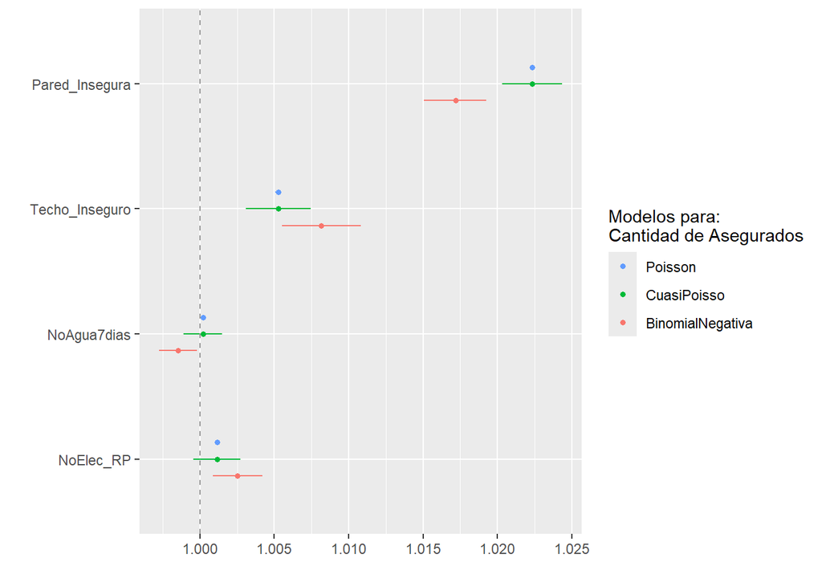

```r
library(ggplot2)
library(dotwhisker)

dotwhisker::dwplot(list(Poisson=rp4,CuasiPoisso=rqp,BinomialNegativa=rbn),exp=T) + scale_y_discrete(labels=c("NoElec_RP","NoAgua7dias","Techo_Inseguro","Pared_Insegura")) + scale_color_discrete(name="Modelos para:\nCantidad de Asegurados") + geom_vline(
           xintercept = 1,
           colour = "grey60",
           linetype = 2
       )
```

En el gráfico vemos que ningún intervalo de confianza de la Binomial Negativa pasa por el 1, por lo que confirmamos una vez más que es el mejor modelo.